# NYPD Shooting Incident Data

2023-05-30

### Import Data

- The data set includes a list of every shooting incident in New York City starting in 2006. Data source from here: https://catalog.data.gov/dataset/nypd-shooting-incident-data-historic
- My analysis focused on looking at incident count by various categories. I first focused on location by bourough, to see if there was a different in incidents by location. After that, I looked at incidents based on demographics of the perpetrators. I also looked a linear model of the total incidents over time to look at that trend.

### Tidy data

- Clean up the data by changing the OCCUR_DATE column to date, removing unwanted columns, changing headings, changing variables to factors, and sorting the data by date.
- Below is the final summary and first 10 rows of the data frame. I removed NA’s, but also plan to filter out “(null)” or “UNKNOWN” values if needed for the analysis.

```
##       Date                Time                   Borough        Precinct
##  Min.   :2006-01-01   Length:17968      BRONX        :5425   Min.   :  1.00
##  1st Qu.:2008-08-06   Class1:hms        BROOKLYN     :6642   1st Qu.: 43.00
##  Median :2011-11-19   Class2:difftime   MANHATTAN    :2542   Median : 67.00
##  Mean   :2013-05-11   Mode  :numeric    QUEENS       :2728   Mean   : 65.17
##  3rd Qu.:2018-04-26                     STATEN ISLAND: 631   3rd Qu.: 81.00
##  Max.   :2022-12-31                                          Max.   :123.00
##
##     Perp_Age      Perp_Sex              Perp_Race        Vic_Age     Vic_Sex
##  18-24  :6222   (null):  640   BLACK         :11432   <18    :2027   F: 1922
##  25-44  :5687   F     :  424   WHITE HISPANIC: 2341   1022   :   1   M:16038
##  UNKNOWN:3148   M     :15439   UNKNOWN       : 1802   18-24  :6518   U:    8
##  <18    :1591   U     : 1465   BLACK HISPANIC: 1314   25-44  :7939
##  (null) : 640                  (null)        :  640   45-64  :1290
##  45-64  : 617                  WHITE         :  283   65+    : 137
##  (Other):  63                  (Other)       :  156   UNKNOWN:  56
##                            Vic_Race         Year
##  AMERICAN INDIAN/ALASKAN NATIVE:    8   Length:17968
##  ASIAN / PACIFIC ISLANDER      :  307   Class :character
##  BLACK                         :12252   Mode  :character
##  BLACK HISPANIC                : 1800
##  UNKNOWN                       :   48
##  WHITE                         :  552
##  WHITE HISPANIC                : 3001
```

```
##          Date     Time       Borough Precinct Perp_Age Perp_Sex      Perp_Race
## 1  2006-01-01 05:51:00         BRONX       44    25-44        M WHITE HISPANIC
## 2  2006-01-01 02:22:00     MANHATTAN       28    25-44        M          BLACK
## 3  2006-01-01 03:30:00      BROOKLYN       67  UNKNOWN        U        UNKNOWN
## 4  2006-01-01 02:34:00        QUEENS      114    18-24        M          BLACK
## 5  2006-01-01 19:00:00        QUEENS      106    18-24        M          BLACK
## 6  2006-01-01 02:34:00        QUEENS      114    25-44        M          BLACK
## 7  2006-01-01 02:00:00         BRONX       48    18-24        M          BLACK
## 8  2006-01-02 00:49:00      BROOKLYN       90  UNKNOWN        U        UNKNOWN
## 9  2006-01-02 10:53:00 STATEN ISLAND      120    18-24        M          BLACK
## 10 2006-01-02 03:59:00      BROOKLYN       70    18-24        M          BLACK
##    Vic_Age Vic_Sex       Vic_Race Year
## 1    18-24       M WHITE HISPANIC 2006
## 2    25-44       M          BLACK 2006
## 3    18-24       M          BLACK 2006
## 4    25-44       M          BLACK 2006
## 5    18-24       M          BLACK 2006
## 6    25-44       M          BLACK 2006
## 7      <18       M          BLACK 2006
## 8    25-44       M          BLACK 2006
## 9    18-24       M          BLACK 2006
## 10   18-24       M          BLACK 2006
```

### Visualization #1: Number of shooting incidents each year, by Borough

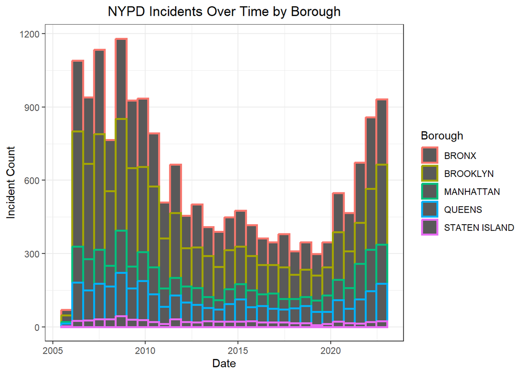

### Visualization #2: Perpetrator Age and Sex

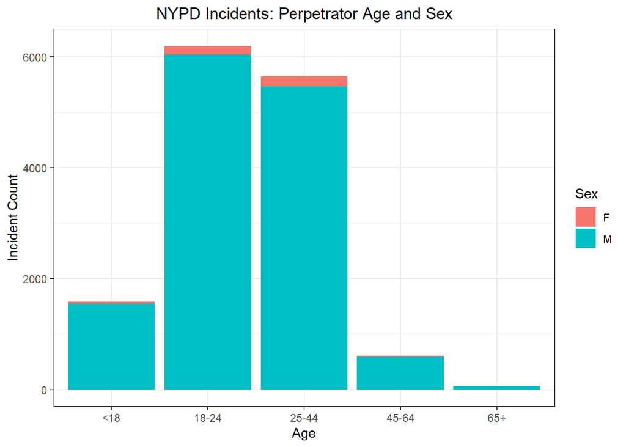

### Model: Linear Regression of Incidents over time and summary of model

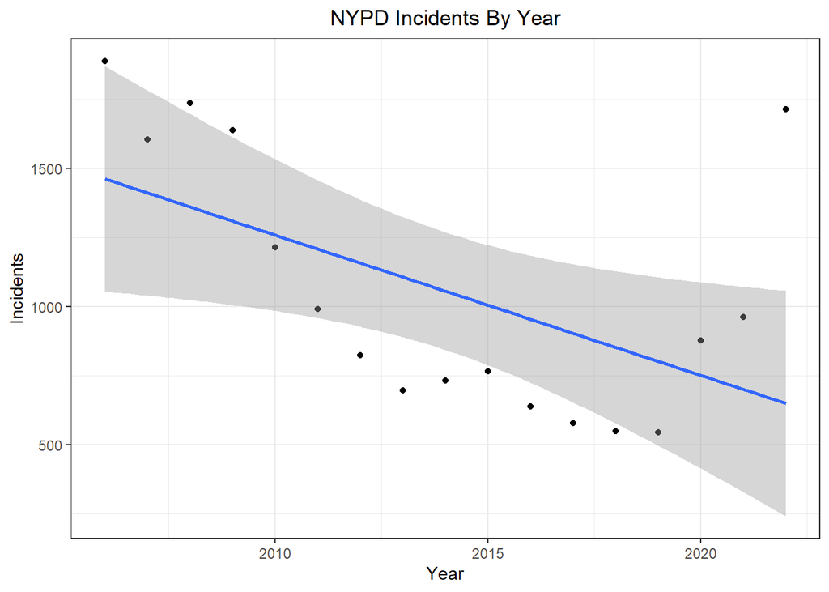

```
##
## Call:
## lm(formula = Incidents ~ Year, data = NYPD_Yearly)
##
## Residuals:
##    Min     1Q Median     3Q    Max
## -409.8 -315.3 -217.3  260.7 1065.5
##
## Coefficients:
##              Estimate Std. Error t value Pr(>|t|)
## (Intercept) 103376.04   41058.06   2.518   0.0237 *
## Year           -50.80      20.39  -2.492   0.0249 *
## ---
## Signif. codes:  0 '***' 0.001 '**' 0.01 '*' 0.05 '.' 0.1 ' ' 1
##
## Residual standard error: 411.8 on 15 degrees of freedom
## Multiple R-squared:  0.2928, Adjusted R-squared:  0.2457
## F-statistic:  6.21 on 1 and 15 DF,  p-value: 0.02489
```

### Conclusion and Bias

- There were some differences between the different boroughs and number of incidents. While it appears Staten Island is the lowest, it only includes total numbers, but not the proportion of incidents to population. We would need to calculate the proportion for each section in order to compare them and prevent bias.
- For the bar chart, it’s clear that the main perpetrators were males in the 18-24 and 25-44 age ranges.This confirms a personal bias, but I wanted to include male vs female to see the differences.
- There may be a correlation between year and the number of shooting incidents in New York.While I only tried a linear model, there may be better models that will better fit the data. There is an outlier for the last year, and the acutal data indicates more of a curve, instead of a straight line.